# Monthly deaths from Lung Diseases

Time Series

Author

Oscar Hernandez Mata

```r
library(car)
library(ltsa)
library(itsmr)
library(astsa)
library(forecast)
library(aTSA)
library(tidyverse)
library(tsibble)
library(feasts)
library(dplyr)
library(astsa)
library(Metrics)
library(datasets)
library(ggplot2)
```

# Time Series Modeling and Forecasting

I am going to study the monthly deaths from Lung Diseases (bronchitis, emphysema and asthma) in the UK, from 1974 to 1979. There are three data sets: 1) `ldeaths` contains the total monthly deaths, 2) `mdeaths` has only males monthly deaths and 3) `fdeaths` has females monthly deaths. Note that ldeaths= fdeaths+ mdeaths.

The goal is to build a model for forecasting the monthly deaths from Lung Diseases in the UK. Steps I considered in my analysis:

I splited each dataset to 2 datasets: i) The Training dataset contains observations from 1974 to 1978 and ii) the Testing dataset has the data of 1979.

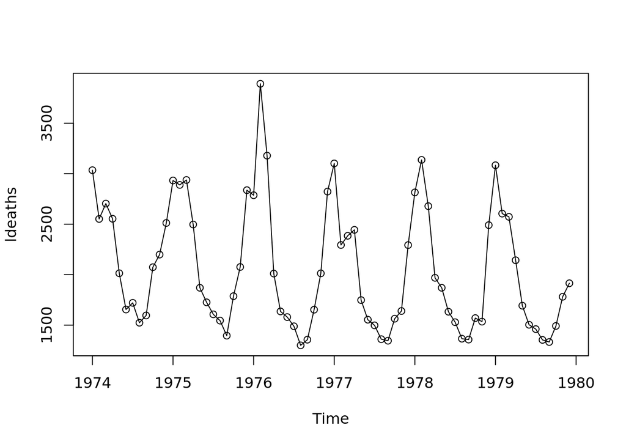

```r
plot(ldeaths, type="o")
```

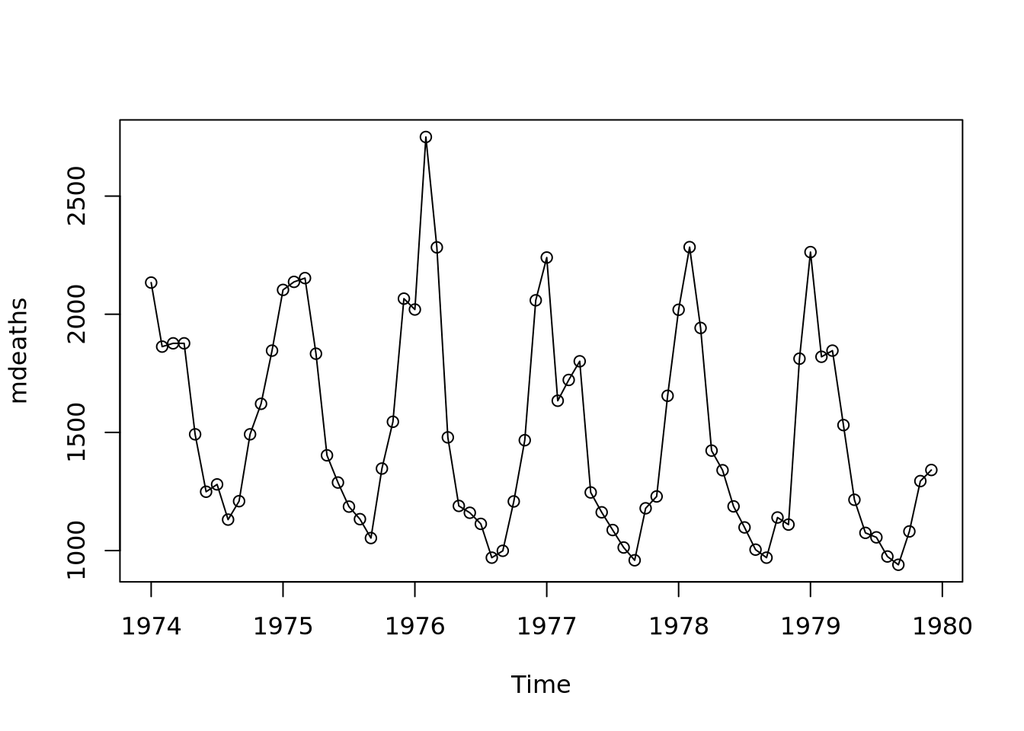

```r
plot(mdeaths, type="o")
```

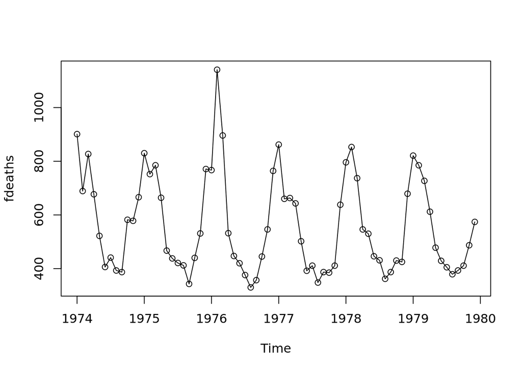

```r
plot(fdeaths, type="o")
```

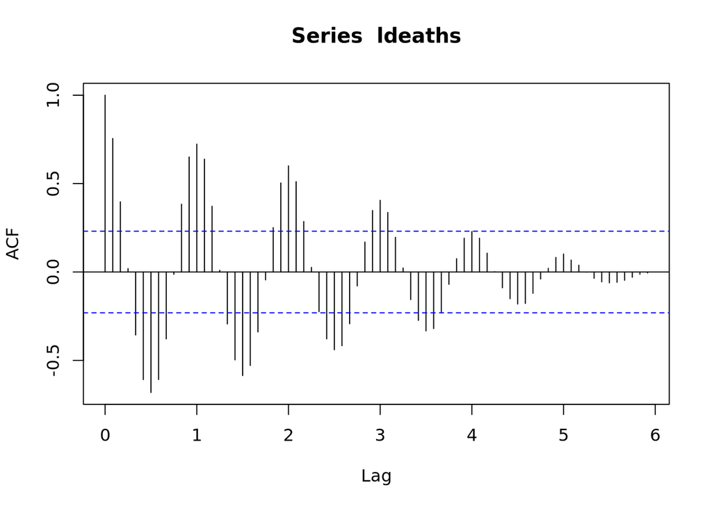

```r
acf(ldeaths,lag.max = 100)
```

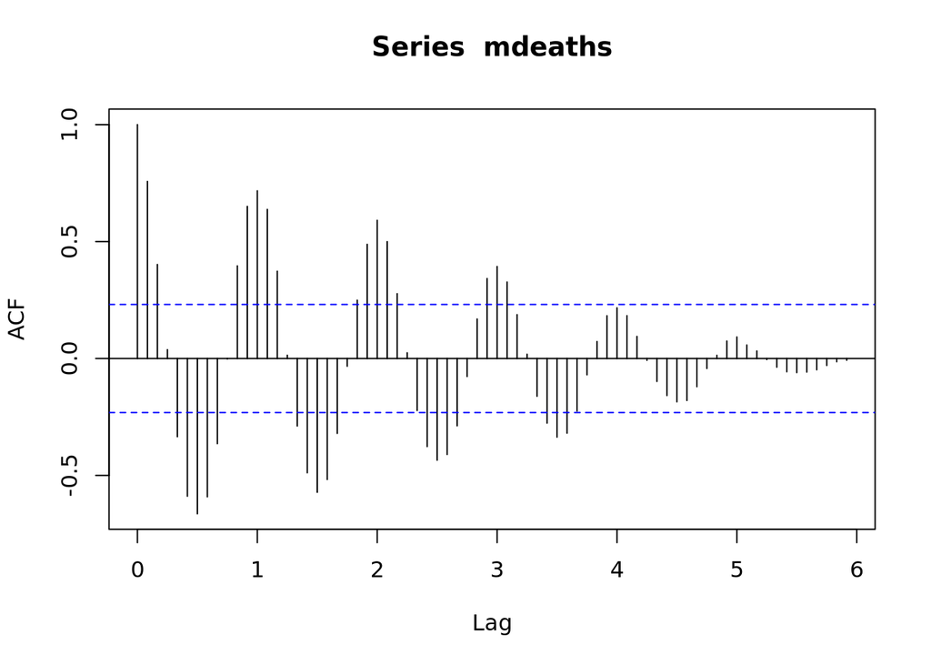

```r
acf(mdeaths,lag.max = 100)
```

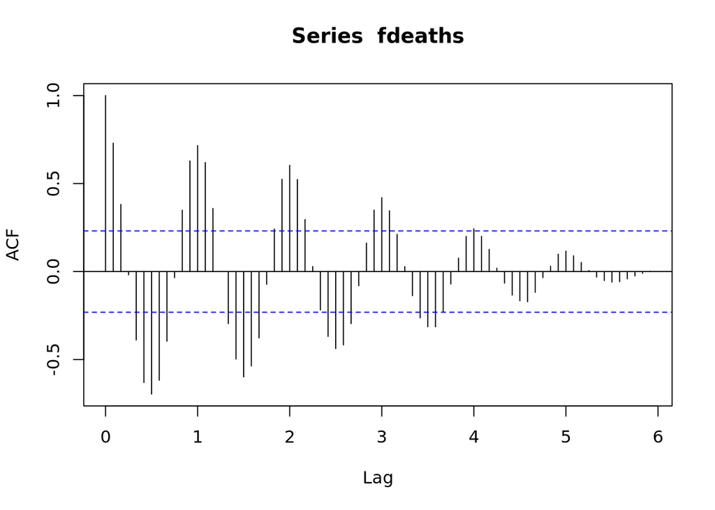

```r
acf(fdeaths,lag.max = 100)
```

```
Null hypothesis: Residuals are iid noise.
Test                        Distribution Statistic   p-value
Ljung-Box Q                Q ~ chisq(20)    425.12         0 *
McLeod-Li Q                Q ~ chisq(20)    351.43         0 *
Turning points T   (T-46.7)/3.5 ~ N(0,1)        23         0 *
Diff signs S       (S-35.5)/2.5 ~ N(0,1)        30    0.0258 *
Rank P           (P-1278)/102.9 ~ N(0,1)      1013      0.01 *
```

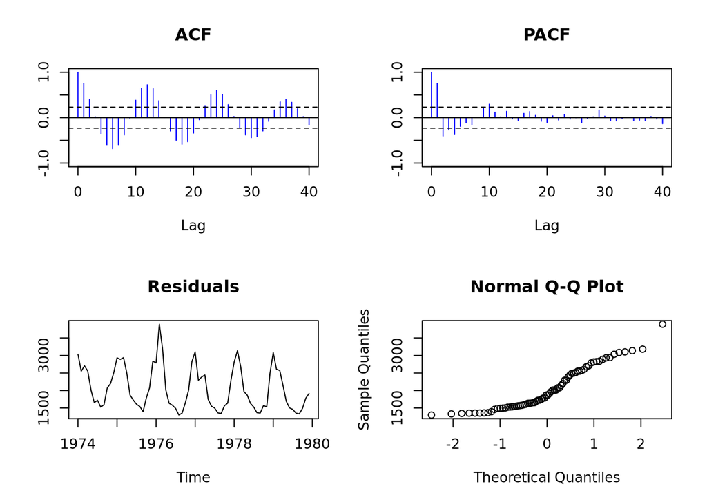

```r
test(ldeaths)
```

```
Null hypothesis: Residuals are iid noise.
Test                        Distribution Statistic   p-value
Ljung-Box Q                Q ~ chisq(20)    413.45         0 *
McLeod-Li Q                Q ~ chisq(20)    350.23         0 *
Turning points T   (T-46.7)/3.5 ~ N(0,1)        22         0 *
Diff signs S       (S-35.5)/2.5 ~ N(0,1)        32    0.1559
Rank P           (P-1278)/102.9 ~ N(0,1)       988    0.0048 *
```

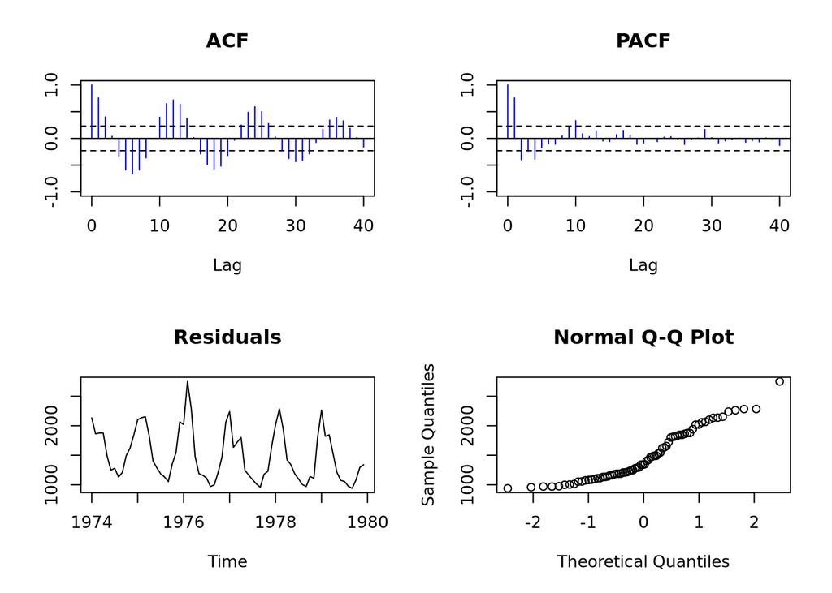

```r
test(mdeaths)
```

```
Null hypothesis: Residuals are iid noise.
Test                        Distribution Statistic   p-value
Ljung-Box Q                Q ~ chisq(20)    425.93         0 *
McLeod-Li Q                Q ~ chisq(20)     327.6         0 *
Turning points T   (T-46.7)/3.5 ~ N(0,1)        29         0 *
Diff signs S       (S-35.5)/2.5 ~ N(0,1)        30    0.0258 *
Rank P           (P-1278)/102.9 ~ N(0,1)      1102    0.0871
```

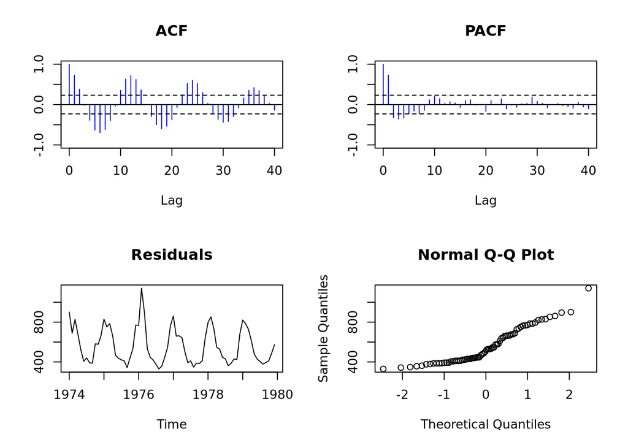

```r
test(fdeaths)
```

```
Null hypothesis: Residuals are iid noise.
Test                        Distribution Statistic   p-value
Ljung-Box Q                Q ~ chisq(20)      66.4         0 *
McLeod-Li Q                Q ~ chisq(20)     51.74     1e-04 *
Turning points T     (T-38)/3.2 ~ N(0,1)        34    0.2097
Diff signs S         (S-29)/2.2 ~ N(0,1)        28    0.6547
Rank P           (P-855.5)/76.5 ~ N(0,1)       859    0.9635
```

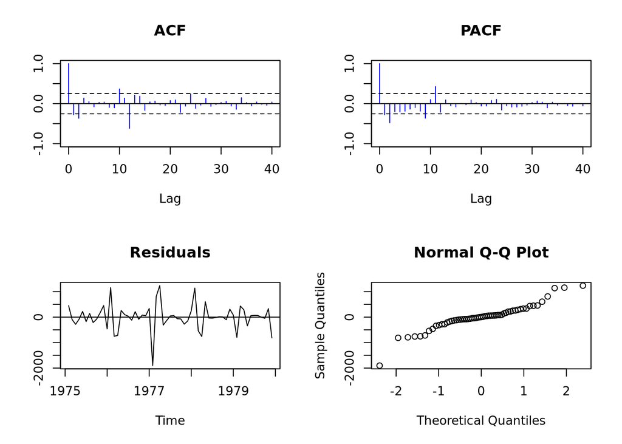

```r
mldeaths1=c("diff",1,"diff",12)
rldeaths1 = Resid(ldeaths,mldeaths1)
test(rldeaths1)
```

```r
adf.test(rldeaths1)
```

```
Augmented Dickey-Fuller Test
alternative: stationary

Type 1: no drift no trend
     lag    ADF p.value
[1,]   0  -9.97    0.01
[2,]   1 -10.10    0.01
[3,]   2  -7.25    0.01
[4,]   3  -6.37    0.01
Type 2: with drift no trend
     lag    ADF p.value
[1,]   0  -9.88    0.01
[2,]   1 -10.01    0.01
[3,]   2  -7.18    0.01
[4,]   3  -6.31    0.01
Type 3: with drift and trend
     lag   ADF p.value
[1,]   0 -9.79    0.01
[2,]   1 -9.91    0.01
[3,]   2 -7.10    0.01
[4,]   3 -6.23    0.01
----
Note: in fact, p.value = 0.01 means p.value <= 0.01
```

```
Null hypothesis: Residuals are iid noise.
Test                        Distribution Statistic   p-value
Ljung-Box Q                Q ~ chisq(20)     71.66         0 *
McLeod-Li Q                Q ~ chisq(20)     55.33         0 *
Turning points T     (T-38)/3.2 ~ N(0,1)        36    0.5305
Diff signs S         (S-29)/2.2 ~ N(0,1)        29         1
Rank P           (P-855.5)/76.5 ~ N(0,1)       844    0.8804
```

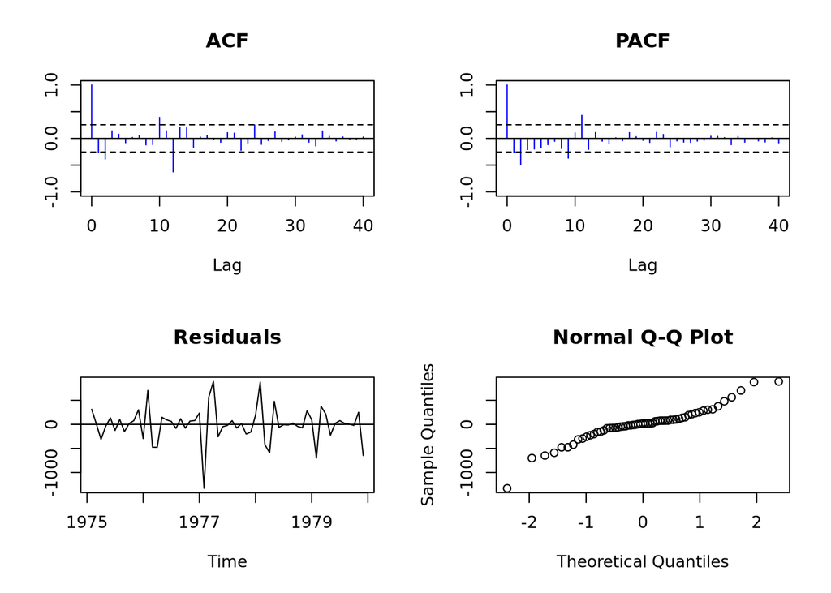

```r
mmdeaths1=c("diff",1,"diff",12)
rmdeaths1 = Resid(mdeaths,mmdeaths1)
test(rmdeaths1)
```

```r
adf.test(rmdeaths1)
```

```
Augmented Dickey-Fuller Test
alternative: stationary

Type 1: no drift no trend
     lag    ADF p.value
[1,]   0  -9.86    0.01
[2,]   1 -10.39    0.01
[3,]   2  -7.44    0.01
[4,]   3  -6.47    0.01
Type 2: with drift no trend
     lag    ADF p.value
[1,]   0  -9.77    0.01
[2,]   1 -10.29    0.01
[3,]   2  -7.37    0.01
[4,]   3  -6.42    0.01
Type 3: with drift and trend
     lag    ADF p.value
[1,]   0  -9.68    0.01
[2,]   1 -10.19    0.01
[3,]   2  -7.29    0.01
[4,]   3  -6.33    0.01
----
Note: in fact, p.value = 0.01 means p.value <= 0.01
```

```
Null hypothesis: Residuals are iid noise.
Test                        Distribution Statistic   p-value
Ljung-Box Q                Q ~ chisq(20)      50.8     2e-04 *
McLeod-Li Q                Q ~ chisq(20)     42.46    0.0024 *
Turning points T     (T-38)/3.2 ~ N(0,1)        42    0.2097
Diff signs S         (S-29)/2.2 ~ N(0,1)        28    0.6547
Rank P           (P-855.5)/76.5 ~ N(0,1)       846    0.9011
```

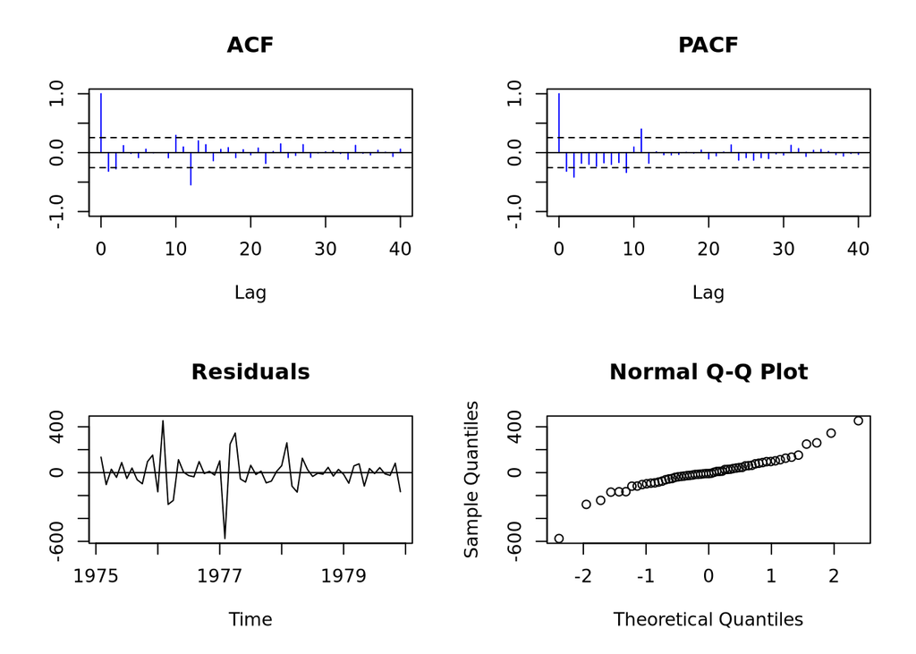

```r
mfdeaths1=c("diff",1,"diff",12)
rfdeaths1 = Resid(fdeaths,mfdeaths1)
test(rfdeaths1)
```

```r
adf.test(rfdeaths1)
```

```
Augmented Dickey-Fuller Test
alternative: stationary

Type 1: no drift no trend
     lag    ADF p.value
[1,]   0 -10.50    0.01
[2,]   1  -9.39    0.01
[3,]   2  -6.88    0.01
[4,]   3  -6.06    0.01
Type 2: with drift no trend
     lag    ADF p.value
[1,]   0 -10.40    0.01
[2,]   1  -9.30    0.01
[3,]   2  -6.81    0.01
[4,]   3  -6.00    0.01
Type 3: with drift and trend
     lag    ADF p.value
[1,]   0 -10.31    0.01
[2,]   1  -9.21    0.01
[3,]   2  -6.74    0.01
[4,]   3  -5.94    0.01
----
Note: in fact, p.value = 0.01 means p.value <= 0.01
```

```
Null hypothesis: Residuals are iid noise.
Test                        Distribution Statistic   p-value
Ljung-Box Q                Q ~ chisq(20)     10.27     0.963
McLeod-Li Q                Q ~ chisq(20)     14.53    0.8027
Turning points T   (T-46.7)/3.5 ~ N(0,1)        42    0.1865
Diff signs S       (S-35.5)/2.5 ~ N(0,1)        31    0.0681
Rank P           (P-1278)/102.9 ~ N(0,1)      1255    0.8231
```

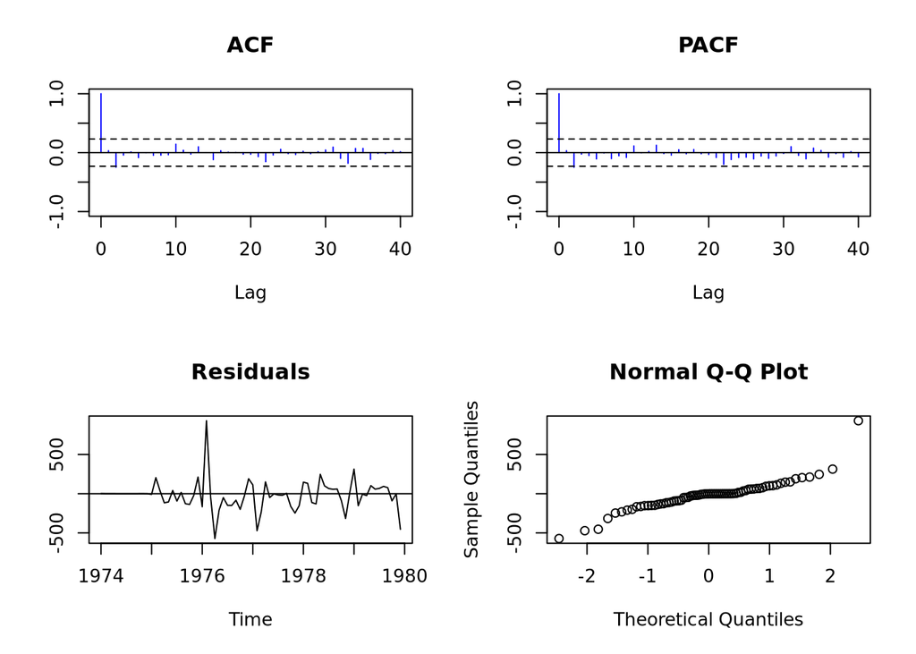

```r
# Potential Values for ldeaths
# based on the PACF

#p=0, 1, 2, 9, 11
#P=0, 1

#q=0,1, 2, 10
#Q=0,1

# Eliminate Trend and Season
# d = 1
# D = 1


fitldeaths1 = arima(ldeaths,
            order = c(1,1,1),
            seasonal = list(order=c(1,1,1),period=12))

test(fitldeaths1$residuals)
```

```
Null hypothesis: Residuals are iid noise.
Test                        Distribution Statistic   p-value
Ljung-Box Q                Q ~ chisq(20)      8.11    0.9911
McLeod-Li Q                Q ~ chisq(20)      4.42    0.9999
Turning points T   (T-46.7)/3.5 ~ N(0,1)        44    0.4503
Diff signs S       (S-35.5)/2.5 ~ N(0,1)        34    0.5431
Rank P           (P-1278)/102.9 ~ N(0,1)      1314    0.7263
```

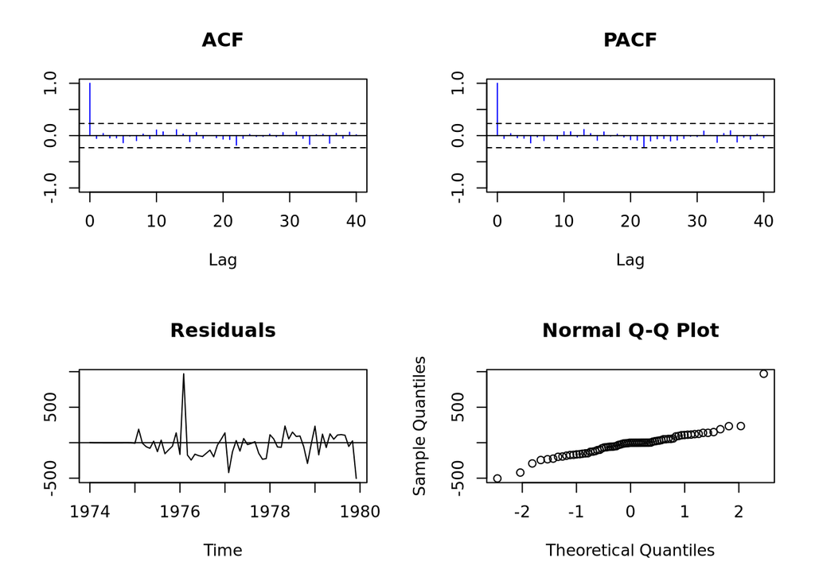

```r
fitldeaths2 = arima(ldeaths,
            order = c(2,1,2),
            seasonal = list(order=c(1,1,1),period=12))

test(fitldeaths2$residuals)
```

```r
bestmodelldeaths = auto.arima(ldeaths, trace= TRUE)
```

```
 ARIMA(2,0,2)(1,1,1)[12] with drift         : Inf
 ARIMA(0,0,0)(0,1,0)[12] with drift         : 880.4252
 ARIMA(1,0,0)(1,1,0)[12] with drift         : 859.3667
 ARIMA(0,0,1)(0,1,1)[12] with drift         : Inf
 ARIMA(0,0,0)(0,1,0)[12]                    : 879.5963
 ARIMA(1,0,0)(0,1,0)[12] with drift         : 882.3707
 ARIMA(1,0,0)(2,1,0)[12] with drift         : 850.3567
 ARIMA(1,0,0)(2,1,1)[12] with drift         : Inf
 ARIMA(1,0,0)(1,1,1)[12] with drift         : Inf
 ARIMA(0,0,0)(2,1,0)[12] with drift         : 849.4512
 ARIMA(0,0,0)(1,1,0)[12] with drift         : 858.6241
 ARIMA(0,0,0)(2,1,1)[12] with drift         : Inf
 ARIMA(0,0,0)(1,1,1)[12] with drift         : Inf
 ARIMA(0,0,1)(2,1,0)[12] with drift         : 848.6208
 ARIMA(0,0,1)(1,1,0)[12] with drift         : 857.257
 ARIMA(0,0,1)(2,1,1)[12] with drift         : Inf
 ARIMA(0,0,1)(1,1,1)[12] with drift         : Inf
 ARIMA(1,0,1)(2,1,0)[12] with drift         : 849.8721
 ARIMA(0,0,2)(2,1,0)[12] with drift         : 848.2589
 ARIMA(0,0,2)(1,1,0)[12] with drift         : 855.7322
 ARIMA(0,0,2)(2,1,1)[12] with drift         : Inf
 ARIMA(0,0,2)(1,1,1)[12] with drift         : Inf
 ARIMA(1,0,2)(2,1,0)[12] with drift         : Inf
 ARIMA(0,0,3)(2,1,0)[12] with drift         : 849.0507
 ARIMA(1,0,3)(2,1,0)[12] with drift         : 851.4635
 ARIMA(0,0,2)(2,1,0)[12]                    : 857.4225

 Best model: ARIMA(0,0,2)(2,1,0)[12] with drift
```

```
Null hypothesis: Residuals are iid noise.
Test                        Distribution Statistic   p-value
Ljung-Box Q                Q ~ chisq(20)     12.44    0.9001
McLeod-Li Q                Q ~ chisq(20)      2.56         1
Turning points T   (T-46.7)/3.5 ~ N(0,1)        46    0.8503
Diff signs S       (S-35.5)/2.5 ~ N(0,1)        36    0.8394
Rank P           (P-1278)/102.9 ~ N(0,1)      1311    0.7483
```

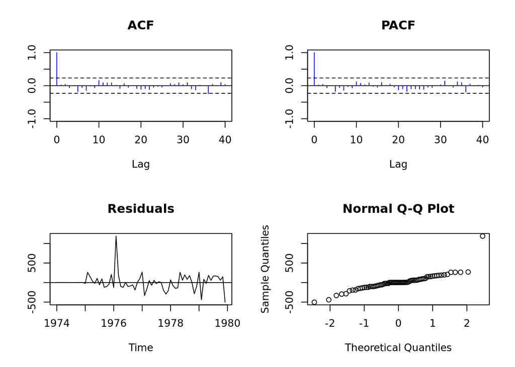

```r
test(bestmodelldeaths$residuals)
```

```r
fitldeaths1
```

```
Call:
arima(x = ldeaths, order = c(1, 1, 1), seasonal = list(order = c(1, 1, 1), period = 12))

Coefficients:
         ar1      ma1     sar1     sma1
      0.2158  -1.0000  -0.2855  -1.0000
s.e.  0.1367   0.0891   0.1389   0.4469

sigma^2 estimated as 44221:  log likelihood = -415.69,  aic = 841.38
```

```r
fitldeaths2
```

```
Call:
arima(x = ldeaths, order = c(2, 1, 2), seasonal = list(order = c(1, 1, 1), period = 12))

Coefficients:
         ar1      ar2      ma1      ma2     sar1     sma1
      0.0745  -0.2841  -0.7743  -0.2257  -0.3025  -0.9999
s.e.  0.3460   0.1712   0.3724   0.3548   0.1429   0.9313

sigma^2 estimated as 39542:  log likelihood = -412.92,  aic = 839.84
```

```r
bestmodelldeaths
```

```
Series: ldeaths
ARIMA(0,0,2)(2,1,0)[12] with drift

Coefficients:
         ma1      ma2     sar1     sar2    drift
      0.1844  -0.2477  -0.9533  -0.5024  -5.5270
s.e.  0.1487   0.1469   0.1325   0.1305   1.1477

sigma^2 = 56263:  log likelihood = -417.34
AIC=846.67   AICc=848.26   BIC=859.24
```

```r
#bestmodel is fitldeaths2 (2,1,2) (1,1,1), AIC= 839.84
```

```
Null hypothesis: Residuals are iid noise.
Test                        Distribution Statistic   p-value
Ljung-Box Q                Q ~ chisq(20)     35.63     0.017 *
McLeod-Li Q                Q ~ chisq(20)     29.04    0.0869
Turning points T   (T-46.7)/3.5 ~ N(0,1)        46    0.8503
Diff signs S       (S-35.5)/2.5 ~ N(0,1)        34    0.5431
Rank P           (P-1278)/102.9 ~ N(0,1)      1285    0.9457
```

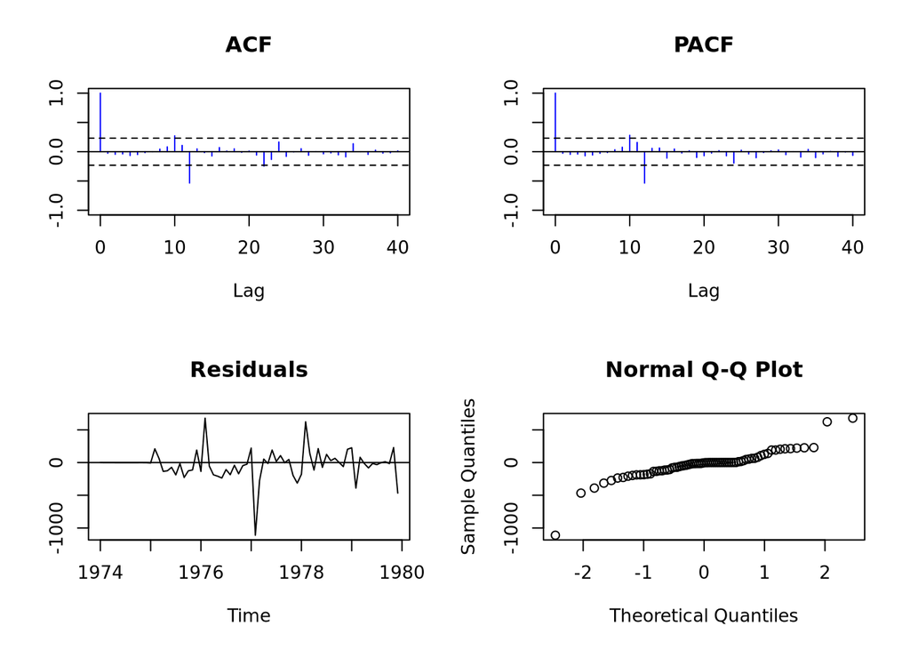

```r
# Potential Values for mdeaths
# based on the PACF

#p=0, 2, 9, 11
#P=0

#q=0,2, 10
#Q=0,1

# Eliminate Trend and Season
# d = 1
# D = 1

fitmdeaths1 = arima(mdeaths,
            order = c(2,1,2),
            seasonal = list(order=c(0,1,0),period=12))

test(fitmdeaths1$residuals)
```

```
Null hypothesis: Residuals are iid noise.
Test                        Distribution Statistic   p-value
Ljung-Box Q                Q ~ chisq(20)      4.51    0.9999
McLeod-Li Q                Q ~ chisq(20)     10.47    0.9589
Turning points T   (T-46.7)/3.5 ~ N(0,1)        52    0.1311
Diff signs S       (S-35.5)/2.5 ~ N(0,1)        34    0.5431
Rank P           (P-1278)/102.9 ~ N(0,1)      1247    0.7631
```

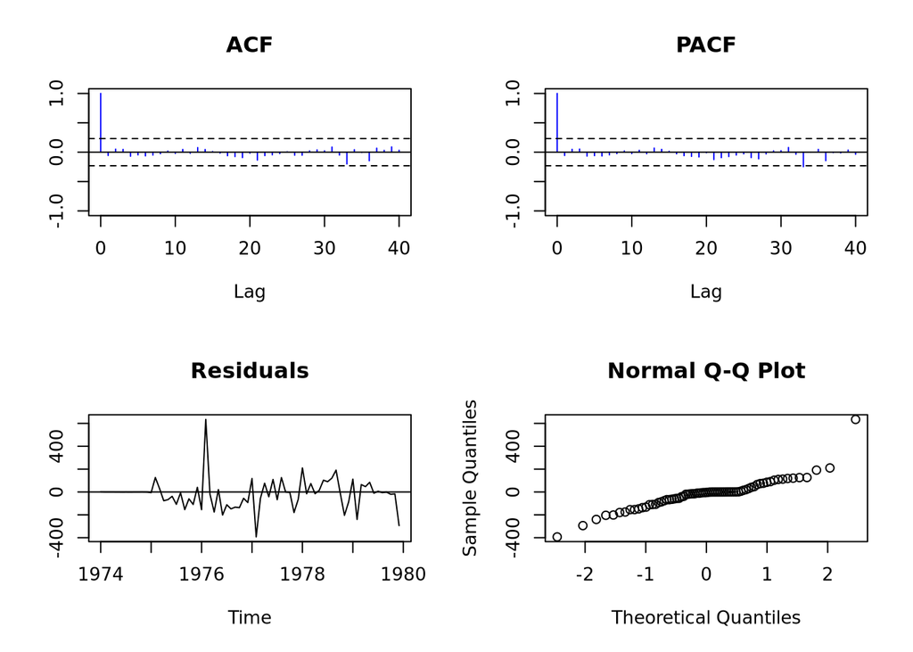

```r
fitmdeaths2 = arima(mdeaths,
            order = c(9,1,10),
            seasonal = list(order=c(0,1,1),period=12))

test(fitmdeaths2$residuals)
```

```r
bestmodelmdeaths = auto.arima(mdeaths, trace= TRUE)
```

```
 ARIMA(2,0,2)(1,1,1)[12] with drift         : 812.6957
 ARIMA(0,0,0)(0,1,0)[12] with drift         : 841.5768
 ARIMA(1,0,0)(1,1,0)[12] with drift         : 819.3659
 ARIMA(0,0,1)(0,1,1)[12] with drift         : Inf
 ARIMA(0,0,0)(0,1,0)[12]                    : 841.1271
 ARIMA(2,0,2)(0,1,1)[12] with drift         : Inf
 ARIMA(2,0,2)(1,1,0)[12] with drift         : 818.5493
 ARIMA(2,0,2)(2,1,1)[12] with drift         : Inf
 ARIMA(2,0,2)(1,1,2)[12] with drift         : Inf
 ARIMA(2,0,2)(0,1,0)[12] with drift         : 842.6886
 ARIMA(2,0,2)(0,1,2)[12] with drift         : 812.7409
 ARIMA(2,0,2)(2,1,0)[12] with drift         : Inf
 ARIMA(2,0,2)(2,1,2)[12] with drift         : Inf
 ARIMA(1,0,2)(1,1,1)[12] with drift         : Inf
 ARIMA(2,0,1)(1,1,1)[12] with drift         : 810.2523
 ARIMA(2,0,1)(0,1,1)[12] with drift         : Inf
 ARIMA(2,0,1)(1,1,0)[12] with drift         : 816.1449
 ARIMA(2,0,1)(2,1,1)[12] with drift         : 812.8359
 ARIMA(2,0,1)(1,1,2)[12] with drift         : 812.8829
 ARIMA(2,0,1)(0,1,0)[12] with drift         : 840.777
 ARIMA(2,0,1)(0,1,2)[12] with drift         : 810.4495
 ARIMA(2,0,1)(2,1,0)[12] with drift         : 810.15
 ARIMA(1,0,1)(2,1,0)[12] with drift         : 810.1285
 ARIMA(1,0,1)(1,1,0)[12] with drift         : 817.3854
 ARIMA(1,0,1)(2,1,1)[12] with drift         : Inf
 ARIMA(1,0,1)(1,1,1)[12] with drift         : Inf
 ARIMA(0,0,1)(2,1,0)[12] with drift         : 808.6436
 ARIMA(0,0,1)(1,1,0)[12] with drift         : 816.47
 ARIMA(0,0,1)(2,1,1)[12] with drift         : Inf
 ARIMA(0,0,1)(1,1,1)[12] with drift         : Inf
 ARIMA(0,0,0)(2,1,0)[12] with drift         : 809.8688
 ARIMA(0,0,2)(2,1,0)[12] with drift         : 808.7496
 ARIMA(1,0,0)(2,1,0)[12] with drift         : 810.5831
 ARIMA(1,0,2)(2,1,0)[12] with drift         : Inf
 ARIMA(0,0,1)(2,1,0)[12]                    : 817.0729

 Best model: ARIMA(0,0,1)(2,1,0)[12] with drift
```

```
Null hypothesis: Residuals are iid noise.
Test                        Distribution Statistic   p-value
Ljung-Box Q                Q ~ chisq(20)     10.72    0.9532
McLeod-Li Q                Q ~ chisq(20)      6.31    0.9984
Turning points T   (T-46.7)/3.5 ~ N(0,1)        42    0.1865
Diff signs S       (S-35.5)/2.5 ~ N(0,1)        37    0.5431
Rank P           (P-1278)/102.9 ~ N(0,1)      1259    0.8534
```

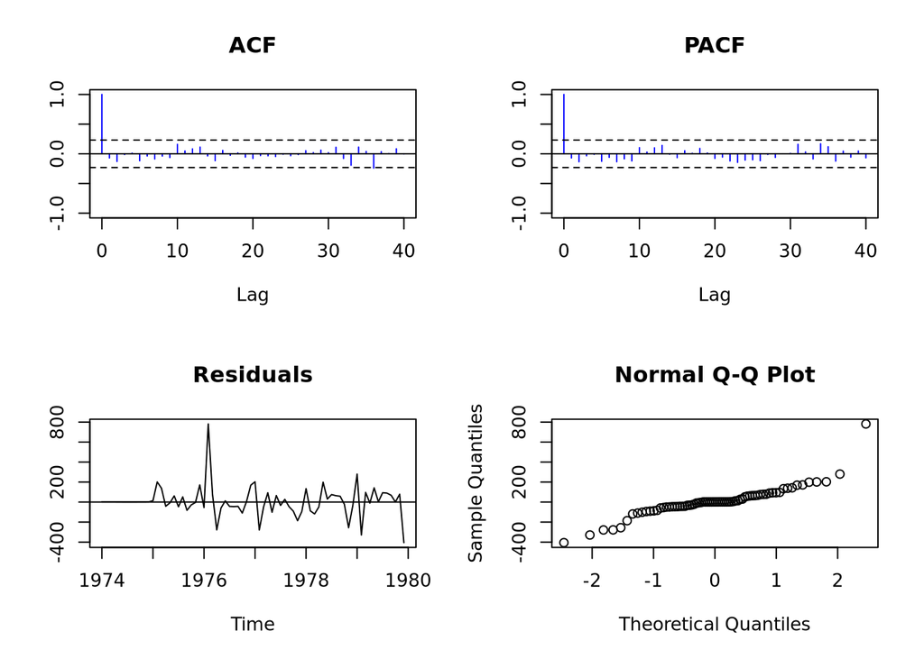

```r
test(bestmodelmdeaths$residuals)
```

```r
fitmdeaths1
```

```
Call:
arima(x = mdeaths, order = c(2, 1, 2), seasonal = list(order = c(0, 1, 0), period = 12))

Coefficients:
          ar1      ar2      ma1      ma2
      -0.1194  -0.3156  -0.7463  -0.2537
s.e.   0.3845   0.1406   0.4189   0.4142

sigma^2 estimated as 60043:  log likelihood = -410.61,  aic = 831.22
```

```r
fitmdeaths2
```

```
Call:
arima(x = mdeaths, order = c(9, 1, 10), seasonal = list(order = c(0, 1, 1),
    period = 12))

Coefficients:
          ar1      ar2      ar3      ar4      ar5      ar6      ar7      ar8
      -0.4562  -1.2959  -0.3808  -1.3845  -0.5758  -1.2893  -0.4678  -0.6554
s.e.   0.5593   0.2576   0.8402   0.2423   0.8773   0.2292   0.8357   0.3034
          ar9      ma1     ma2      ma3     ma4      ma5     ma6      ma7
      -0.2203  -0.1537  0.4753  -0.6954  0.9566  -0.4224  0.7318  -0.7783
s.e.   0.5120   0.5341  0.3690   0.5109  0.4809   0.6131  0.5665   0.5243
         ma8      ma9    ma10     sma1
      0.1693  -0.4806  0.2168  -0.6152
s.e.  0.5236   0.4192  0.5299   0.2174

sigma^2 estimated as 21203:  log likelihood = -388.36,  aic = 818.72
```

```r
bestmodelmdeaths
```

```
Series: mdeaths
ARIMA(0,0,1)(2,1,0)[12] with drift

Coefficients:
         ma1     sar1     sar2    drift
      0.3517  -1.0245  -0.5120  -4.5670
s.e.  0.1563   0.1286   0.1296   1.1454

sigma^2 = 29046:  log likelihood = -398.77
AIC=807.53   AICc=808.64   BIC=818
```

```r
#The best model is auto.arima ARIMA(0,0,1)(2,1,0)[12], AIC=807.53
```

```
Null hypothesis: Residuals are iid noise.
Test                        Distribution Statistic   p-value
Ljung-Box Q                Q ~ chisq(20)      8.29    0.9897
McLeod-Li Q                Q ~ chisq(20)      4.38    0.9999
Turning points T   (T-46.7)/3.5 ~ N(0,1)        48    0.7058
Diff signs S       (S-35.5)/2.5 ~ N(0,1)        35    0.8394
Rank P           (P-1278)/102.9 ~ N(0,1)      1339    0.5531
```

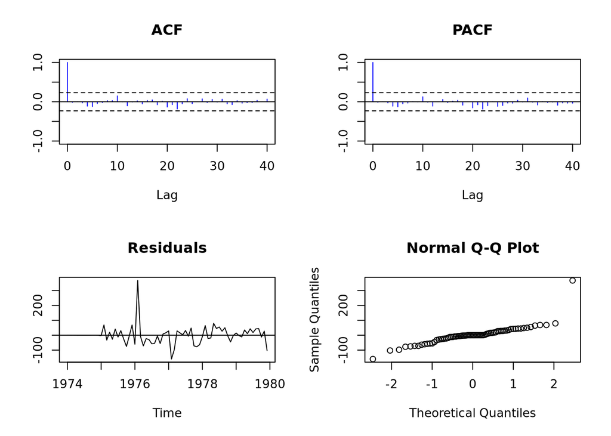

```r
# Potential Values for fdeaths
# based on the PACF

#p=0, 1, 2, 11
#P=0

#q=0,1, 10
#Q=0,1

# Eliminate Trend and Season
# d = 1
# D = 1

fitfdeaths1 = arima(fdeaths,
            order = c(2,1,1),
            seasonal = list(order=c(0,1,1),period=12))

test(fitfdeaths1$residuals)
```

```
Null hypothesis: Residuals are iid noise.
Test                        Distribution Statistic   p-value
Ljung-Box Q                Q ~ chisq(20)      9.54    0.9758
McLeod-Li Q                Q ~ chisq(20)      1.85         1
Turning points T   (T-46.7)/3.5 ~ N(0,1)        46    0.8503
Diff signs S       (S-35.5)/2.5 ~ N(0,1)        31    0.0681
Rank P           (P-1278)/102.9 ~ N(0,1)      1312     0.741
```

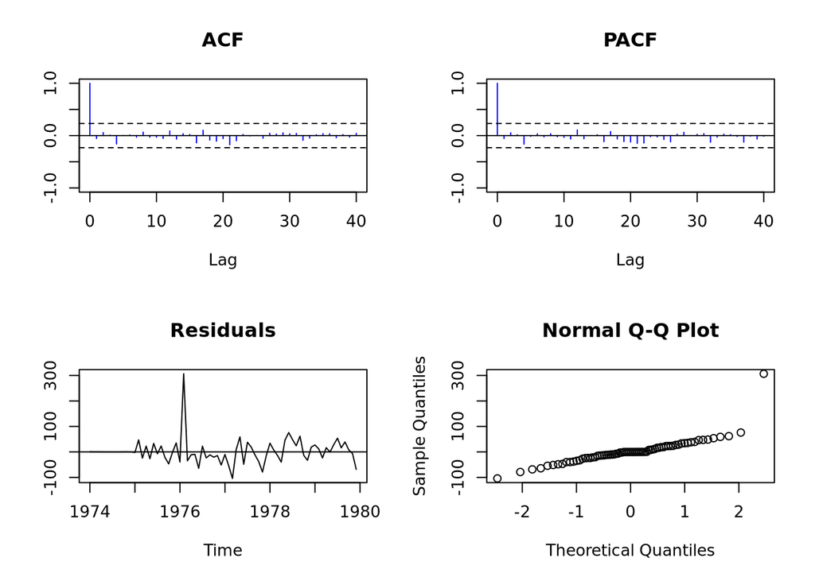

```r
fitfdeaths2 = arima(fdeaths,
            order = c(11,1,10),
            seasonal = list(order=c(0,1,1),period=12))

test(fitfdeaths2$residuals)
```

[output not shown]

```r
bestmodelfdeaths = auto.arima(fdeaths, trace= TRUE)
```

```
 ARIMA(2,0,2)(1,1,1)[12] with drift         : Inf
 ARIMA(0,0,0)(0,1,0)[12] with drift         : 735.0779
 ARIMA(1,0,0)(1,1,0)[12] with drift         : 717.9657
 ARIMA(0,0,1)(0,1,1)[12] with drift         : Inf
 ARIMA(0,0,0)(0,1,0)[12]                    : 733.4053
 ARIMA(1,0,0)(0,1,0)[12] with drift         : 736.8396
 ARIMA(1,0,0)(2,1,0)[12] with drift         : 710.3874
 ARIMA(1,0,0)(2,1,1)[12] with drift         : Inf
 ARIMA(1,0,0)(1,1,1)[12] with drift         : Inf
 ARIMA(0,0,0)(2,1,0)[12] with drift         : 708.4859
 ARIMA(0,0,0)(1,1,0)[12] with drift         : 716.0469
 ARIMA(0,0,0)(2,1,1)[12] with drift         : Inf
 ARIMA(0,0,0)(1,1,1)[12] with drift         : Inf
 ARIMA(0,0,1)(2,1,0)[12] with drift         : 710.098
 ARIMA(1,0,1)(2,1,0)[12] with drift         : 711.498
 ARIMA(0,0,0)(2,1,0)[12]                    : 710.8345

 Best model: ARIMA(0,0,0)(2,1,0)[12] with drift
```

```
Null hypothesis: Residuals are iid noise.
Test                        Distribution Statistic   p-value
Ljung-Box Q                Q ~ chisq(20)      9.97    0.9687
McLeod-Li Q                Q ~ chisq(20)      3.31         1
Turning points T   (T-46.7)/3.5 ~ N(0,1)        50    0.3453
Diff signs S       (S-35.5)/2.5 ~ N(0,1)        33    0.3108
Rank P           (P-1278)/102.9 ~ N(0,1)      1363    0.4086
```

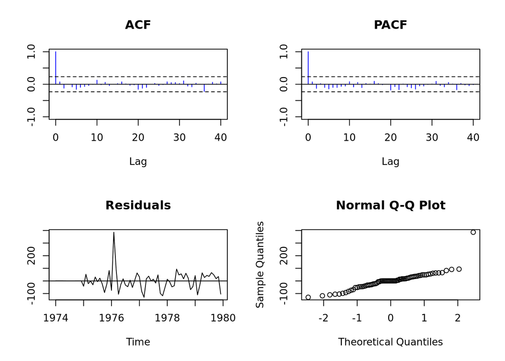

```r
test(bestmodelfdeaths$residuals)
```

```r
fitfdeaths1
```

```
Call:
arima(x = fdeaths, order = c(2, 1, 1), seasonal = list(order = c(0, 1, 1), period = 12))

Coefficients:
         ar1      ar2      ma1     sma1
      0.1190  -0.2023  -1.0000  -1.0000
s.e.  0.1309   0.1362   0.0903   0.2785

sigma^2 estimated as 4614:  log likelihood = -346.14,  aic = 702.29
```

```r
fitfdeaths2
```

```
Call:
arima(x = fdeaths, order = c(11, 1, 10), seasonal = list(order = c(0, 1, 1),
    period = 12))

Coefficients:
          ar1      ar2      ar3      ar4      ar5     ar6     ar7     ar8
      -1.0255  -0.8418  -0.4405  -0.4566  -0.3402  0.0646  0.0426  0.0465
s.e.   0.8878   1.6881   2.2164   2.2767   2.2233  2.0397  1.5354  1.0820
          ar9    ar10    ar11     ma1      ma2      ma3     ma4      ma5
      -0.2000  0.2331  0.2564  0.3178  -0.2578  -0.5707  0.1238  -0.1328
s.e.   0.7222  0.6120  0.3114  0.9003   1.0970   0.8336  0.4345   0.3351
          ma6      ma7     ma8     ma9     ma10     sma1
      -0.8563  -0.2828  0.3146  0.6688  -0.3222  -0.8177
s.e.   0.4022   0.9889  1.1047  0.7650   0.4636   0.5448

sigma^2 estimated as 2990:  log likelihood = -339.98,  aic = 725.97
```

```r
bestmodelfdeaths
```

```
Series: fdeaths
ARIMA(0,0,0)(2,1,0)[12] with drift

Coefficients:
         sar1     sar2    drift
      -0.8721  -0.4950  -0.9642
s.e.   0.1266   0.1298   0.4139

sigma^2 = 5887:  log likelihood = -349.88
AIC=707.76   AICc=708.49   BIC=716.14
```

```r
#The best model is fitfdeaths1 (2,1,1) (0,1,1)    AIC=702.29
```

```r
ldeaths_train = ldeaths[1:60]
mdeaths_train = mdeaths[1:60]
fdeaths_train = fdeaths[1:60]
```

**I fited a time series model to the training `ldeaths` data set. Then I ploted the data, ACF, and PACF. Next, I described and discuss the steps I followed. Finally I wrote down the equation of the model.**

In order to find an adequate time series model for all the training datasets I first checked for seasonality and trends. Next I checked iid noise. The datasets reveals seasonality and slight downward trend. Thus, I used difference in operartors to eliminate the trend and seasonality. Then, I checked iid again, and stationary. The results showed a stationary data. Finally, I looked for p, q, d, P, D, Q appropiate indicators using the ACF, and PACF graphics to come up with the more adequate model comparing AICs.

```
Null hypothesis: Residuals are iid noise.
Test                        Distribution Statistic   p-value
Ljung-Box Q                Q ~ chisq(20)      7.11    0.9963
McLeod-Li Q                Q ~ chisq(20)      3.97         1
Turning points T   (T-38.7)/3.2 ~ N(0,1)        35    0.2543
Diff signs S       (S-29.5)/2.3 ~ N(0,1)        28    0.5059
Rank P             (P-885)/78.4 ~ N(0,1)       813    0.3584
```

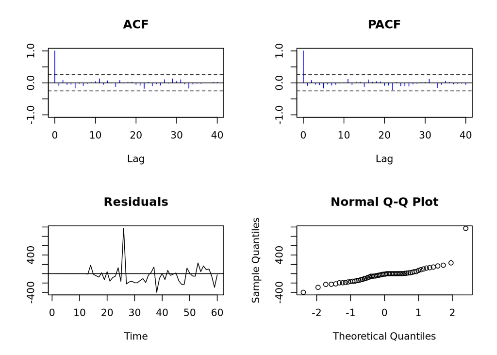

```r
fitldeaths_train1 = arima(ldeaths_train,
            order = c(2,1,2),
            seasonal = list(order=c(1,1,1),period=12))

test(fitldeaths_train1$residuals)
```

$$(1 - 0.0745B + 0.2841B^2)(1 - B)X_t = (1 - 0.7743B - 0.2257B^2)\varepsilon_t
(1 + 0.3025B^{12})(1 - B^{12})X_t = (1 - 0.9999B^{12})\Z_t$$

```
Null hypothesis: Residuals are iid noise.
Test                        Distribution Statistic   p-value
Ljung-Box Q                Q ~ chisq(20)     12.82    0.8851
McLeod-Li Q                Q ~ chisq(20)      13.8    0.8406
Turning points T   (T-38.7)/3.2 ~ N(0,1)        39    0.9175
Diff signs S       (S-29.5)/2.3 ~ N(0,1)        28    0.5059
Rank P             (P-885)/78.4 ~ N(0,1)       831    0.4909
```

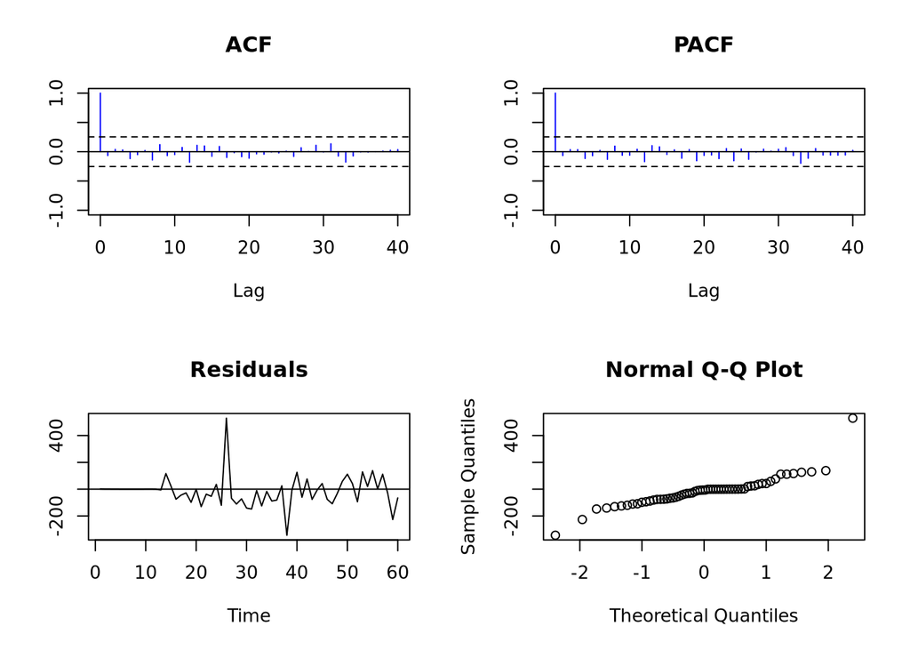

```r
#bestmodelmdeaths_train = auto.arima(mdeaths_train, trace= TRUE)

#test(bestmodelmdeaths_train$residuals) #iid compromised

fitmdeaths_train1 = arima(mdeaths_train,
            order = c(9,1,10),
            seasonal = list(order=c(0,1,1),period=12))

test(fitmdeaths_train1$residuals)  #iid not compromised
```

```
Null hypothesis: Residuals are iid noise.
Test                        Distribution Statistic   p-value
Ljung-Box Q                Q ~ chisq(20)      8.53    0.9877
McLeod-Li Q                Q ~ chisq(20)      3.95         1
Turning points T   (T-38.7)/3.2 ~ N(0,1)        39    0.9175
Diff signs S       (S-29.5)/2.3 ~ N(0,1)        29    0.8245
Rank P             (P-885)/78.4 ~ N(0,1)       863     0.779
```

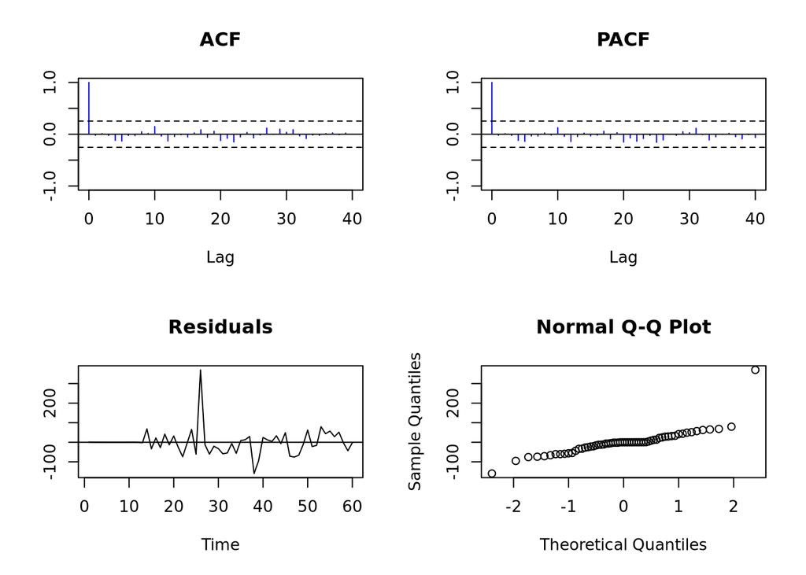

```r
fitfdeaths_train1=arima(fdeaths_train,
            order = c(2,1,1),
            seasonal = list(order=c(0,1,1),period=12))

test(fitfdeaths_train1$residuals)
```

I provided a forecast points for a year ahead (12 observations) for the three datasets (totals, males, and females).

```
Forecast for univariate time series:
   Lead Forecast S.E Lower Upper
61    1     2831 229  2381  3280
62    2     2704 246  2222  3186
63    3     2541 251  2049  3033
64    4     2142 251  1649  2634
65    5     1555 253  1059  2051
66    6     1381 254   884  1879
67    7     1323 253   826  1819
68    8     1185 253   689  1682
69    9     1165 254   668  1662
70   10     1506 253  1009  2002
71   11     1775 252  1280  2269
72   12     2433 253  1938  2929
------
Note: confidence level = 95 %
```

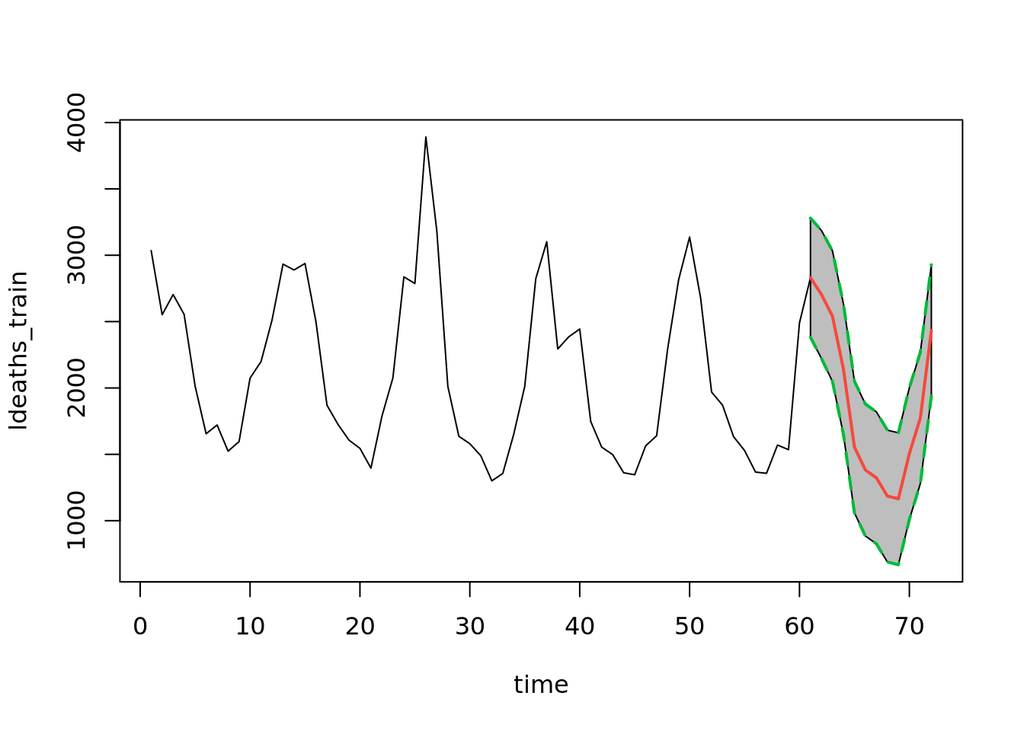

```r
fitldeaths_train2 = aTSA::forecast(object = fitldeaths_train1,lead = 12,output = TRUE)
```

```
Forecast for univariate time series:
   Lead Forecast S.E Lower Upper
61    1     1899 145  1615  2183
62    2     1982 159  1669  2294
63    3     1792 161  1477  2107
64    4     1455 160  1141  1770
65    5     1232 163   913  1551
66    6     1226 167   899  1554
67    7     1040 168   710  1370
68    8      796 168   466  1125
69    9      808 168   478  1138
70   10     1045 173   707  1384
71   11     1238 180   884  1592
72   12     1832 188  1464  2200
------
Note: confidence level = 95 %
```

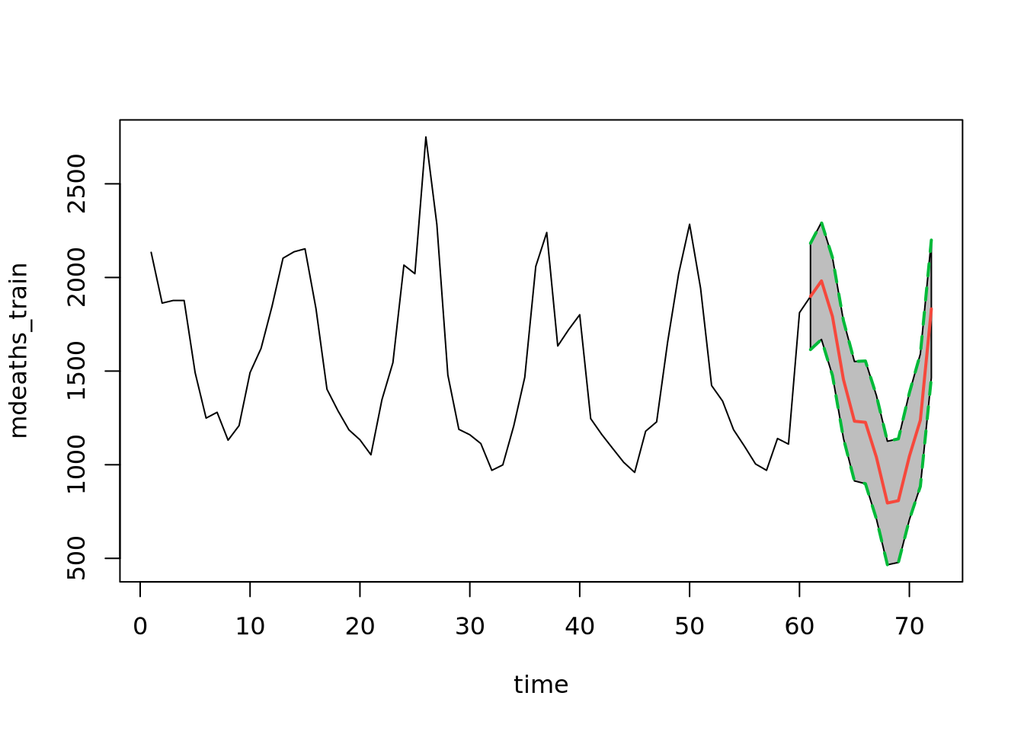

```r
fitmdeaths_train2 = aTSA::forecast(object = fitmdeaths_train1,lead = 12,output = TRUE)
```

```
Forecast for univariate time series:
   Lead Forecast  S.E Lower Upper
61    1      806 82.8   643   968
62    2      785 83.9   621   950
63    3      742 84.8   575   908
64    4      574 84.8   408   740
65    5      456 85.0   290   623
66    6      383 85.1   216   550
67    7      379 85.0   212   545
68    8      332 85.0   165   499
69    9      335 85.0   168   501
70   10      417 85.0   250   583
71   11      460 84.8   293   626
72   12      674 84.9   508   841
------
Note: confidence level = 95 %
```

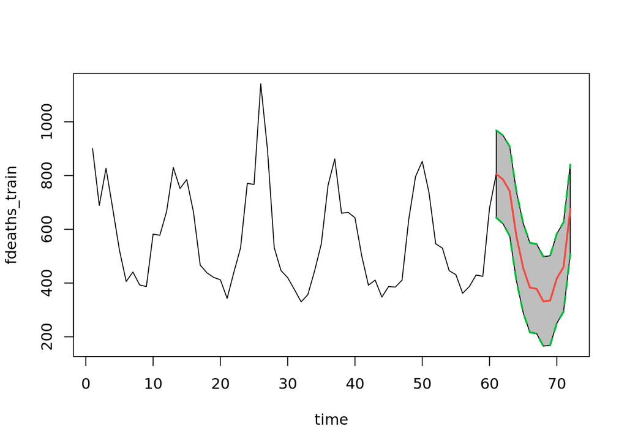

```r
fitfdeaths_train2 = aTSA::forecast(object = fitfdeaths_train1,lead = 12,output = TRUE)
```

I fitted ARAR and Holt-Winters models to the three time series data (ldeaths, fdeaths, and mdeaths)

```
Optimal lags 1 10 12 24
Optimal coeffs 0.07344124 0.1835476 -0.6012546 -0.2809034
WN Variance 89122.12
Filter 1 -0.07344124 0 0 0 0 0 0 0 0 -0.1835476 0 -0.3671471 0.07112063 0 0 0 0 0 0 0 0 0.1777478 0 -0.3013526 0 0 0 0 0 0 0 0 0 0 0 -0.2720274

 Step     Prediction      sqrt(MSE)    Lower Bound    Upper Bound
    1       2848.254       298.5333       2263.129       3433.379
    2       2871.607       299.3373       2284.906       3458.308
    3       2621.549       299.3416       2034.839       3208.258
    4       2066.117       299.3416       1479.408       2652.827
    5       1718.587       299.3416       1131.877       2305.296
    6       1533.828       299.3416       947.1185       2120.538
    7       1458.316       299.3416        871.606       2045.025
    8        1307.97       299.3416       721.2599       1894.679
    9       1295.997       299.3416       709.2869       1882.706
   10       1579.849       299.3416       993.1392       2166.558
   11       1666.318       304.3155       1069.859       2262.776
   12       2390.327       304.4219        1793.66       2986.994
```

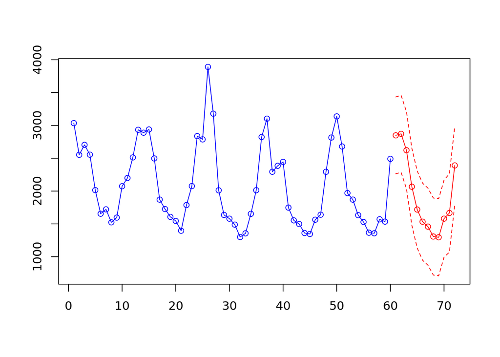

```r
ldeaths_arar.prd = arar(ldeaths_train, h=12)
```

```
Optimal lags 1 10 12 24
Optimal coeffs 0.07736416 0.2101178 -0.5613554 -0.2765714
WN Variance 45802.66
Filter 1 -0.07736416 0 0 0 0 0 0 0 0 -0.2101178 0 -0.4068521 0.07490456 0 0 0 0 0 0 0 0 0.2034376 0 -0.2669371 0 0 0 0 0 0 0 0 0 0 0 -0.2677786

 Step     Prediction      sqrt(MSE)    Lower Bound    Upper Bound
    1       2053.897       214.0156       1634.426       2473.367
    2       2061.753       214.6551       1641.029       2482.477
    3       1897.274       214.6589       1476.543       2318.005
    4       1489.745       214.6589       1069.014       1910.477
    5       1234.075       214.6589       813.3438       1654.807
    6       1123.379       214.6589       702.6478       1544.111
    7       1061.302       214.6589       640.5702       1482.033
    8       957.8396       214.6589       537.1081       1378.571
    9       919.9189       214.6589       499.1875        1340.65
   10       1164.227       214.6589       743.4955       1584.958
   11       1217.665       219.3185       787.8011        1647.53
   12       1729.637       219.4289       1299.556       2159.717
```

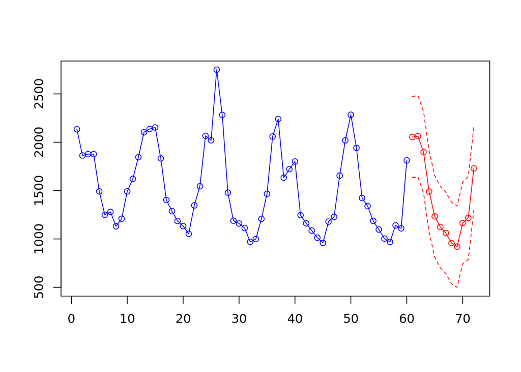

```r
mdeaths_arar.prd = arar(mdeaths_train, h=12)
```

```
Optimal lags 1 10 12 24
Optimal coeffs 0.05238724 0.1330045 -0.6484616 -0.2602666
WN Variance 8408.787
Filter 1 -0.05238724 0 0 0 0 0 0 0 0 -0.1330045 0 -0.3174993 0.05060402 0 0 0 0 0 0 0 0 0.1284771 0 -0.3661219 0 0 0 0 0 0 0 0 0 0 0 -0.2514074

 Step     Prediction      sqrt(MSE)    Lower Bound    Upper Bound
    1       794.5343       91.69944       614.8034       974.2652
    2       807.9243       91.82518       627.9469       987.9016
    3       724.4022       91.82553       544.4241       904.3802
    4       569.3797       91.82553       389.4017       749.3578
    5        488.415       91.82553       308.4369        668.393
    6       410.1685       91.82553       230.1905       590.1466
    7       399.7666       91.82553       219.7885       579.7446
    8        349.419       91.82553       169.4409        529.397
    9       375.2719       91.82553       195.2938       555.2499
   10       415.0241       91.82553        235.046       595.0021
   11       443.3216       92.63197       261.7629       624.8803
   12       658.0761       92.64078       476.5001        839.652
```

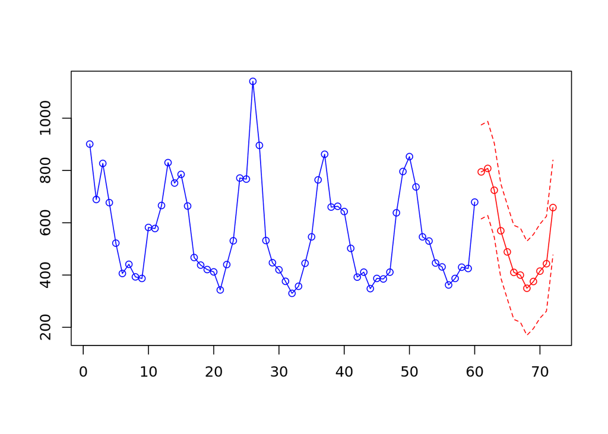

```r
fdeaths_arar.prd = arar(fdeaths_train, h=12)
```

```r
HWmodel_ldeaths = HoltWinters(ts(ldeaths_train,start=1,frequency = 12),seasonal = "mult")
ldeaths_HW.prd =forecast::forecast(HWmodel_ldeaths,12)




HWmodel_mdeaths = HoltWinters(ts(mdeaths_train,start=1,frequency = 12),seasonal = "mult")
mdeaths_HW.prd =forecast::forecast(HWmodel_mdeaths,12)




HWmodel_fdeaths = HoltWinters(ts(fdeaths_train,start=1,frequency = 12),seasonal = "mult")
fdeaths_HW.prd =forecast::forecast(HWmodel_fdeaths,12)
```

I combined the forecasts of male and female deaths. I named it CombinedForecasting= MaleForecasts+ FemaleForecasts. This CombinedForecasting is used to forecast the total monthly deaths.

```r
CombinedForecasting_SARIMA=fitmdeaths_train2+fitfdeaths_train2

OneModelForecasts_SARIMA=fitldeaths_train2 = aTSA::forecast(object = fitldeaths_train1,lead = 12,output = FALSE)
```

```r
CombinedForecasting_ARAR=mdeaths_arar.prd$pred+fdeaths_arar.prd$pred
CombinedForecasting_ARAR
```

```
 [1] 2848.431 2869.678 2621.676 2059.125 1722.490 1533.548 1461.068 1307.259
 [9] 1295.191 1579.251 1660.987 2387.713
```

```r
OneModelForecasts_ARAR= ldeaths_arar.prd$pred
OneModelForecasts_ARAR
```

```
 [1] 2848.254 2871.607 2621.549 2066.117 1718.587 1533.828 1458.316 1307.970
 [9] 1295.997 1579.849 1666.318 2390.327
```

```r
CombinedForecasting_HW=mdeaths_HW.prd$mean+fdeaths_HW.prd$mean
CombinedForecasting_HW
```

```
       Jan      Feb      Mar      Apr      May      Jun      Jul      Aug
6 2542.179 2583.441 2465.584 2030.124 1594.440 1442.843 1394.445 1238.100
       Sep      Oct      Nov      Dec
6 1253.969 1539.096 1653.217 2141.908
```

```r
OneModelForecasts_HW=ldeaths_HW.prd$mean
OneModelForecasts_HW
```

```
       Jan      Feb      Mar      Apr      May      Jun      Jul      Aug
6 2576.472 2606.500 2502.121 2067.027 1610.037 1464.340 1413.160 1258.010
       Sep      Oct      Nov      Dec
6 1267.859 1577.216 1688.490 2166.758
```

By analzing the results of the combined forecast and the one model forecast I noticed the mape percentage are very close in values. For instance the combined forecast SARIMA model reveals an average of 8.7% forecast error of the actual values. On the other hand, the one model forecast shows an average of 7.7% forecast error of the actual values. The difference between the two types of forecasts are very narrow. The other models disclose the same characteristics.

```r
MAPE_SARIMA_Combined = mape(ldeaths[61:72],CombinedForecasting_SARIMA[,2])*100
MAPE_SARIMA_Onemodel = mape(ldeaths[61:72],OneModelForecasts_SARIMA[,2])*100

MAPE_ARAR_Combined = mape(ldeaths[61:72],CombinedForecasting_ARAR)*100
MAPE_ARAR_Onemodel = mape(ldeaths[61:72],OneModelForecasts_ARAR)*100


MAPE_HW_Combined = mape(ldeaths[61:72],CombinedForecasting_HW)*100
MAPE_HW_Onemodel = mape(ldeaths[61:72],OneModelForecasts_HW)*100


MAPEs = c(SARIMA_COMBINED = MAPE_SARIMA_Combined,
          SARIMA_ONEMODEL = MAPE_SARIMA_Onemodel,
          ARAR_MODEL_COMBINED = MAPE_ARAR_Combined,
          ARAR_MODEL_ONEMODEL = MAPE_ARAR_Onemodel,
          HW_MODEL_COMBINED = MAPE_HW_Combined,
          HW_MODEL_ONEMODEL = MAPE_HW_Onemodel)
MAPEs
```

```
    SARIMA_COMBINED     SARIMA_ONEMODEL ARAR_MODEL_COMBINED ARAR_MODEL_ONEMODEL
           8.678207            7.706080            5.906281            5.862950
  HW_MODEL_COMBINED   HW_MODEL_ONEMODEL
           6.579219            5.804555
```

Model

MAPE %

CombinedForecasts - SARIMA

```
8.67820
```

OneModelForecasts - SARIMA

```
7.706080
```

CombinedForecasts - ARAR

```
 5.906281
```

OneModelForecasts - ARAR

```
5.862950
```

CombinedForecasts - HW

```
6.579219
```

OneModelForecasts - HW

```
5.804555
```

[output not shown]

```r
all_models_combined= 8.67820 + 7.706080 +  5.906281 + 5.862950 + 6.579219 + 5.804555 /6
all_models_combined
```

```
[1] 35.70016
```